# Maintain your brain, Primary Cognitive Composite Variable

Pattern Mixture Model Scenario 1

## cogmeanz_full

- Primary Cognitive Composite Variable
  - Cogstate Detection
  - Cogstate Identification
  - Cogstate One Back
  - Cambridge Brain Sciences Spatial (tokens) Search
  - Cambridge Brain Sciences Grammatical Reasoning
  - Cogstate One Card Learning
  - Cambridge Brain Sciences Paired Associates

```r
# read in functions and data
library(tidyverse)
library(mice)
library(emmeans)
library(broom.mixed)
load( file ="../../MI/imputed_wrangeld_25") # loads imp_mids
```

PMM methods for MNAR assumption.

Inference for differences in rc_trial_time trend by group_type_id for cogmeanz_full

## Scenario 1: Constant

People who did not return were people whose scores would have been lower over follow-up time points. This assumes that the imputed missing values are actually lower than the imputation model predicted.

$$MNAR \: imputed \: value = imputed \:
value - constant$$

This maintains the *quality* of the change of the imputed values, but brings the mean and mean change down.

```r
# Change the imputed values to .1 less
pmm_imputed_data_loc <- pmm_imputed_data %>%
  mutate(cogmeanz_full = ifelse(na_flag == 1,
                                cogmeanz_full- params$mnar_coeff,
                                cogmeanz_full))
```

Summary of two of the imputed datasets

```r
pmm_imputed_data_loc %>%
  filter(.imp %in% 1:2) %>%
  group_by(.imp, rc_trial_time, group_type_id) %>%
  summarize_at(.vars = params$response, .funs = list(Mean = mean, Sd = sd, N_obs = ~length(.)), na.rm=T)
```

```
## # A tibble: 16 x 6
## # Groups:   .imp, rc_trial_time [8]
##     .imp rc_trial_time group_type_id    Mean    Sd N_obs
##    <int> <fct>         <fct>           <dbl> <dbl> <int>
##  1     1 1             1              0.0203 1.00   3053
##  2     1 1             2             -0.0180 0.996  3051
##  3     1 10            1              0.201  0.990  3053
##  4     1 10            2              0.314  0.987  3051
##  5     1 11            1              0.175  0.992  3053
##  6     1 11            2              0.314  0.998  3051
##  7     1 12            1              0.0820 1.01   3053
##  8     1 12            2              0.235  1.01   3051
##  9     2 1             1              0.0203 1.00   3053
## 10     2 1             2             -0.0180 0.996  3051
## 11     2 10            1              0.191  0.997  3053
## 12     2 10            2              0.319  0.984  3051
## 13     2 11            1              0.167  1.01   3053
## 14     2 11            2              0.335  0.986  3051
## 15     2 12            1              0.101  1.01   3053
## 16     2 12            2              0.207  1.01   3051
```

```r
#convert back to mids object

pmm_imputed_data_mids <- as.mids(pmm_imputed_data_loc, .imp = ".imp", .id = "time_id")
```

```r
mod_imp_pmm <- with(data = pmm_imputed_data_mids,
                  exp = lme4::lmer(cogmeanz_full ~  #unadjusted
                  rc_trial_time * group_type_id + (1|id_mask)))

mod_imp_0_pmm <- with(data = pmm_imputed_data_mids,
                  exp = lme4::lmer(cogmeanz_full ~  #unadjusted
                  rc_trial_time + group_type_id + (1|id_mask)))


em_imp_3 <- emmeans(mod_imp_pmm,  ~ rc_trial_time * group_type_id,
                  at = list(rc_trial_time = as.factor(c(1,12)) ))
```

[output not shown]

[output not shown]

[output not shown]

[output not shown]

[output not shown]

[output not shown]

[output not shown]

[output not shown]

[output not shown]

[output not shown]

[output not shown]

[output not shown]

[output not shown]

[output not shown]

[output not shown]

[output not shown]

[output not shown]

[output not shown]

[output not shown]

[output not shown]

[output not shown]

[output not shown]

[output not shown]

[output not shown]

[output not shown]

[output not shown]

[output not shown]

[output not shown]

[output not shown]

[output not shown]

[output not shown]

[output not shown]

[output not shown]

[output not shown]

[output not shown]

[output not shown]

[output not shown]

[output not shown]

[output not shown]

[output not shown]

[output not shown]

[output not shown]

[output not shown]

[output not shown]

[output not shown]

[output not shown]

[output not shown]

[output not shown]

[output not shown]

[output not shown]

```r
cont_imp_3 <- contrast(em_imp_3, interaction = c("consec", "consec"))

em_imp_2 <- emmeans(mod_imp_pmm,  ~ rc_trial_time * group_type_id,
                  at = list(rc_trial_time = as.factor(c(1,11)) ))
```

[output not shown]

[output not shown]

[output not shown]

[output not shown]

[output not shown]

[output not shown]

[output not shown]

[output not shown]

[output not shown]

[output not shown]

[output not shown]

[output not shown]

[output not shown]

[output not shown]

[output not shown]

[output not shown]

[output not shown]

[output not shown]

[output not shown]

[output not shown]

[output not shown]

[output not shown]

[output not shown]

[output not shown]

[output not shown]

[output not shown]

[output not shown]

[output not shown]

[output not shown]

[output not shown]

[output not shown]

[output not shown]

[output not shown]

[output not shown]

[output not shown]

[output not shown]

[output not shown]

[output not shown]

[output not shown]

[output not shown]

[output not shown]

[output not shown]

[output not shown]

[output not shown]

[output not shown]

[output not shown]

[output not shown]

[output not shown]

[output not shown]

```r
cont_imp_2 <- contrast(em_imp_2, interaction = c("consec", "consec"))

em_imp_1 <- emmeans(mod_imp_pmm,  ~ rc_trial_time * group_type_id,
                  at = list(rc_trial_time = as.factor(c(1,10)) ))
```

[output not shown]

[output not shown]

[output not shown]

[output not shown]

[output not shown]

[output not shown]

[output not shown]

[output not shown]

[output not shown]

[output not shown]

[output not shown]

[output not shown]

[output not shown]

[output not shown]

[output not shown]

[output not shown]

[output not shown]

[output not shown]

[output not shown]

[output not shown]

[output not shown]

[output not shown]

[output not shown]

[output not shown]

[output not shown]

[output not shown]

[output not shown]

[output not shown]

[output not shown]

[output not shown]

[output not shown]

[output not shown]

[output not shown]

[output not shown]

[output not shown]

[output not shown]

[output not shown]

[output not shown]

[output not shown]

[output not shown]

[output not shown]

[output not shown]

[output not shown]

[output not shown]

[output not shown]

[output not shown]

[output not shown]

[output not shown]

[output not shown]

```r
cont_imp_1 <- contrast(em_imp_1, interaction = c("consec", "consec"))

cond_sum <- bind_rows(summary(cont_imp_1),
                      summary(cont_imp_2),
                      summary(cont_imp_3) )
CI_imp <- bind_rows(confint(cont_imp_1),
                    confint(cont_imp_2),
                    confint(cont_imp_3) ) %>%
  dplyr::select(!c(estimate:df))
cond_sum <- cond_sum %>%
  left_join(CI_imp)
aov_pmm = anova(mod_imp_pmm,mod_imp_0_pmm)
anova_call <- aov_pmm$out$`1 ~~ 2`$result %>%  as.data.frame()
res_tab <- data.frame(response = "cogmeansz_full_pmm1",
                      adjusted = "No",
                      comparison = cond_sum$rc_trial_time_consec,
                      did = round(cond_sum$estimate, 3),
                      LCL = round(CI_imp$asymp.LCL, 3),
                      UCL = round(CI_imp$asymp.UCL,3),
                      zstat = cond_sum$z.ratio,
                      pz = cond_sum$p.value,
                      Fstat = paste0(round(anova_call$F.value,3)," (",
                                       round(anova_call$df1,0),",",round(anova_call$df2,0), ")"),
                      p.value = ifelse (anova_call$`P(>F)` < 0.001, "<0.001", paste("= ",round(anova_call$`P(>F)`,3))))

# make NA the f and p for the change to 12 months and change to 24 months
res_tab[1:2,9:10]<-NA


evidence_unadj = ifelse(res_tab$p.value[3]<0.05, "evidence", "no evidence")
```

*Estimates of Group Differences in Change at each Follow up*

```r
res_tab
```

```
##              response adjusted comparison   did   LCL   UCL    zstat
## 1 cogmeansz_full_pmm1       No     10 - 1 0.148 0.097 0.200 5.630052
## 2 cogmeansz_full_pmm1       No     11 - 1 0.189 0.139 0.238 7.517150
## 3 cogmeansz_full_pmm1       No     12 - 1 0.174 0.121 0.227 6.440396
##             pz          Fstat p.value
## 1 1.801552e-08           <NA>    <NA>
## 2 5.598313e-14           <NA>    <NA>
## 3 1.191625e-10 20.552 (3,344)  <0.001
```

```r
# calculate all ems by time and group
group_time_ems <- emmeans(mod_imp_pmm,  ~ group_type_id + rc_trial_time)
```

[output not shown]

[output not shown]

[output not shown]

[output not shown]

[output not shown]

[output not shown]

[output not shown]

[output not shown]

[output not shown]

[output not shown]

[output not shown]

[output not shown]

[output not shown]

[output not shown]

[output not shown]

[output not shown]

[output not shown]

[output not shown]

[output not shown]

[output not shown]

[output not shown]

[output not shown]

[output not shown]

[output not shown]

[output not shown]

[output not shown]

[output not shown]

[output not shown]

[output not shown]

[output not shown]

[output not shown]

[output not shown]

[output not shown]

[output not shown]

[output not shown]

[output not shown]

[output not shown]

[output not shown]

[output not shown]

[output not shown]

[output not shown]

[output not shown]

[output not shown]

[output not shown]

[output not shown]

[output not shown]

[output not shown]

[output not shown]

[output not shown]

[output not shown]

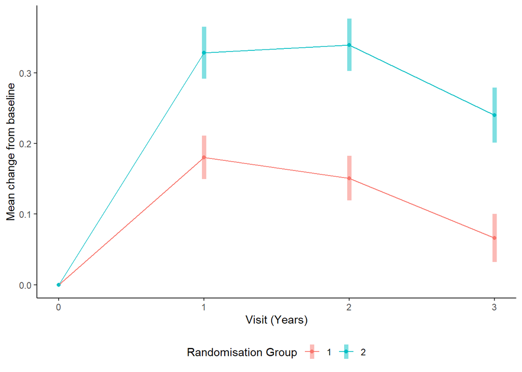

```r
# contrast to baseline by group
comp_to_baseline <- contrast(group_time_ems, rc_trial_time , "trt.vs.ctrl", by=  "group_type_id")


to_bl_plot_df <- cbind(summary(comp_to_baseline)[,1:3],
                       confint(comp_to_baseline)[,6:7],
                       `Visit (Years)` = rep(c(1:3), 2))
# add baseline 0
to_bl_plot_df[7:8,] <- NA
to_bl_plot_df$group_type_id[7:8] = c(1,2)
to_bl_plot_df$estimate[7:8] = c(0,0)
to_bl_plot_df$`Visit (Years)`[7:8] = 0


to_bl_plot_df %>%
  ggplot(aes(`Visit (Years)`, estimate,color=factor(group_type_id), group=factor(group_type_id))) +
  geom_point() +
  geom_line()+
  geom_linerange(aes(ymin=asymp.LCL, ymax=asymp.UCL), size=2, alpha=.5) +
  theme_classic() +
  ylab("Mean change from baseline") +
  scale_color_discrete(name="Randomisation Group")  +
   theme(legend.position = "bottom")
```

```r
ggsave(file = paste0(params$response,"_",params$data,"_pmm1_plot.png"), width = 12, height = 8, units = "cm")
to_bl_plot_df %>%
  transmute(group_type_id, `Visit (Years)`,
         estimate,
         LCL = asymp.LCL, UCL = asymp.UCL) %>%
  arrange(`Visit (Years)`,group_type_id) %>%
write.csv(file = paste0(params$response,"_",params$data,"_pmm1_plotdata.csv"), row.names = FALSE)
```

Now loop to see how much we would have to change to remove the effect (significance?)

## Method

$cogmeanz = cogmeanz - .1 \: if \: imputed$

This results in no change in the *quality* of change implied by the imputed values for each person with missing values, but the means are lower, and the mean change will also be lower.

Further, we calculated the effect size for a range of values of the change to calculate how much lower missing values would need to be to remove the observed effect.

See cogmeanz_imputed.html for a description of the MAR imputation, as well as the models run.

### Results

```r
res_all
```

```
##                  response adjusted comparison    did    LCL   UCL       zstat
## 1   cogmeansz_full_pmm1 0       No     12 - 1  0.193  0.140 0.246  7.16370311
## 2 cogmeansz_full_pmm1 0.1       No     12 - 1  0.174  0.121 0.227  6.44039565
## 3 cogmeansz_full_pmm1 0.2       No     12 - 1  0.154  0.101 0.207  5.70841267
## 4 cogmeansz_full_pmm1 0.5       No     12 - 1  0.096  0.042 0.150  3.49725237
## 5   cogmeansz_full_pmm1 1       No     12 - 1 -0.001 -0.058 0.056 -0.03593722
##             pz          Fstat  p.value
## 1 7.852637e-13 25.357 (3,344)   <0.001
## 2 1.191625e-10 20.552 (3,344)   <0.001
## 3 1.140347e-08 16.248 (3,347)   <0.001
## 4 4.700769e-04  6.652 (3,369)   <0.001
## 5 9.713324e-01  1.842 (3,455) =  0.139
```

The unadjusted difference between randomisation groups of change from baseline to three year follow up was 0.193 ( 95%CI: 0.14- 0.246) baseline standard deviations using multiple imputation assuming MAR, and 0.174 ( 95%CI: 0.121- 0.227) baseline standard deviations assuming missing values were 0.1 baseline standard deviations lower than imputed values (Pattern Mixture Model). To reduce the difference between randomisation groups of change from baseline to three year follow to near zero, missing data would have had to be 1 baseline standard deviation below the level imputed under MAR.

Analysis by Nancy Briggs and Gordana Popovic on 2024-02-14

## References

Li, K. H., T. E. Raghunathan, and D. B. Rubin. 1991. Large-Sample Significance Levels from Multiply Imputed Data Using Moment-Based Statistics and an F Reference Distribution. Journal of the American Statistical Association, 86(416): 1065–73.

Little RJ. Pattern-mixture models for multivariate incomplete data. Journal of the American Statistical Association. 1993;88(421):125–134.

Stef van Buuren, Karin Groothuis-Oudshoorn (2011). mice: Multivariate Imputation by Chained Equations in R. Journal of Statistical Software, 45(3), 1-67. URL https://www.jstatsoft.org/v45/i03/.